# Logarithmic axes with linear gridlines in basic R plots

Petr Keil

July 6, 2016

I like [Mathematica’s](http://media.virtual-maxim.de/uploads/2010/12/ErrorBarLogPlots_Mathmatica.png) and [Matlab’s log-log plots](http://www.mathworks.com/matlabcentral/mlc-downloads/downloads/submissions/35265/versions/2/previews/html/Loglog_Plot_01.png) with logarithmic axes and linear gridlines. In a way, they enable to imagine both multiplication and addition in a single figure. They also enable to more exactly visually connect data points with values.

I haven’t found a simple ‘one-liner’ that’d do such plots in R. In fact, I have always found R’s treatment of logarithmic axes a bit dull - I want the fancy gridlines!

## Function `loglog.plot`

To provide the log-linear gridlines, I have wrtitten function `loglog.plot`.

**To load the function** from my GitHub repository:

```r
source("https://raw.githubusercontent.com/petrkeil/Blog/master/2016_07_05_Log_scales/loglogplot.r")
```

**Arguments:**

`xlim, ylim` - Numeric vectors of length 2, giving the x and y coordinates ranges on linear scale.

`xlog, ylog` - Logical value indicating if x and y axes should be logarithmic (TRUE) or linear (FALSE). In case the linear scale is chosen, no gridlines are drawn.

`xbase, ybase` - Base of the logarithm of the respective axes. Ignored if linear axis is specified.

`...` - Further arguments to the generic R function `plot`.

**Value:**

Empty R base graphics plot, ready to be populated using `lines`, `points` and alike.

## Example 1 - both axes logarithmic

Here I plot three power functions: one sub-linear (exponent = 0.8), one linear (exponent = 1) and one supra-linear (exponent = 1.2).

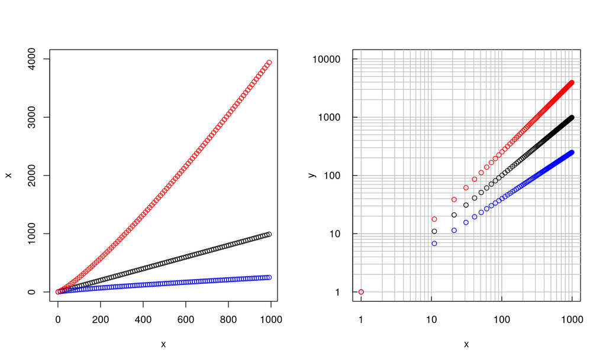

```r
  par(mfrow=c(1,2))
  x <- seq(1, 1000, by=10)

  # left panel - both axes linear
  plot(x, x, ylim=c(0,4000))
  points(x, x^0.8, col="blue")
  points(x, x^1.2, col="red")

  # right panel - loglog plot
  loglog.plot(xlab="x", ylab="y", ylim=c(1, 10000))
  points(log10(x), log10(x))
  points(log10(x), 0.8*log10(x), col="blue")
  points(log10(x), 1.2*log10(x), col="red")
```

## Example 2 - x logarithmic, y linear

In this example I plot a lognormal probability density function, and I only plot the gridlines along the x-axis. The y-axis is linear.

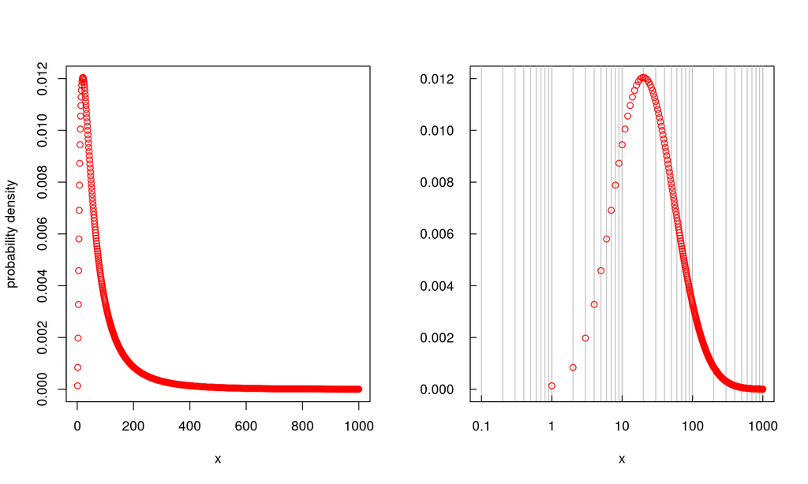

```r
  par(mfrow=c(1,2))
  x <- 1:1000

  # left panel - linear
  plot(x, dlnorm(x, meanlog=4), ylim=c(0, 0.012),
       col="red", ylab="probability density")

  # right panel - loglog plot
  loglog.plot(ylog=FALSE, ylim=c(0,0.012), xlim=c(0.1, 1000),
              xlab="x", ylab="")
  points(log10(x), dlnorm(x, meanlog=4), col="red")
```